# CAR-T QSP Model — Layer 3 Sensitivity & Identifiability (v2)

Log-transformed metrics on a moderate-response baseline

2026-06-07

# 1 Why this v2

The v1 sensitivity analysis produced nonsensically large elasticities (`n_mono` at ~3600, other kinetic parameters in the hundreds), and flagged almost every parameter pair as “unidentifiable” including combinations with no shared mechanism (e.g., `k_growth` vs `Kd_sBCMA` at |cor| = 0.96).

Root cause: the v1 baseline `theta` sat in a strong-response regime where tumor cleared to ~2.6e+04 cells by day 365 and `nadir_sBCMA` hit exactly 0. At these near-zero baselines, the elasticity formula `(ΔM/M)/(Δp/p)` blows up and every kinetic parameter’s sensitivity vector ends up dominated by “distance to the clearance cliff.” The correlation matrix then measures proximity to the cliff rather than each parameter’s distinctive mechanistic fingerprint.

Two fixes in this version:

1. **Moderate-response baseline.** `Vmax_mono` reduced from 0.8 to 0.3 so the low-antigen clone persists meaningfully. `k_growth` reduced from 1.2 to 0.9 so peak expansion lands closer to the clinical 7–21 day window.
2. **Log-transformed metrics with floors.** All metrics spanning many orders of magnitude are `log10(M + floor)` before differencing. The collapsing `nadir_sBCMA` is replaced by `sBCMA_AUC60` (integrated exposure over first 60 days), which is robustly non-zero. The sensitivity formula becomes the clean log-log elasticity `d log10(M) / d log10(p)`.

# 2 Model (unchanged from earlier layers)

# 3 Moderate-response baseline

## 3.1 Baseline sanity check

Before running sensitivity, confirm the baseline is in a moderate regime: CAR-T peak in a realistic window, tumor neither cleared nor uncontrolled, sBCMA meaningfully non-zero.

```
## Baseline summary:
```

```
##   Peak E at day:      25   (want 7-21)
```

```
##   Peak E magnitude:   3.86e+11
```

```
##   Tumor at day 90:    3.94e+09
```

```
##   Tumor at day 365:   4.47e+11   (want 10^7 - 10^11)
```

```
##   Peak sBCMA:         9.94
```

```
##   sBCMA at day 30:    0.063
```

If `tumor_day365` is < 10⁵ or > 10¹¹, the baseline is still at an extreme and `Vmax_mono` needs further adjustment. The sensitivity analysis below is only as trustworthy as this baseline.

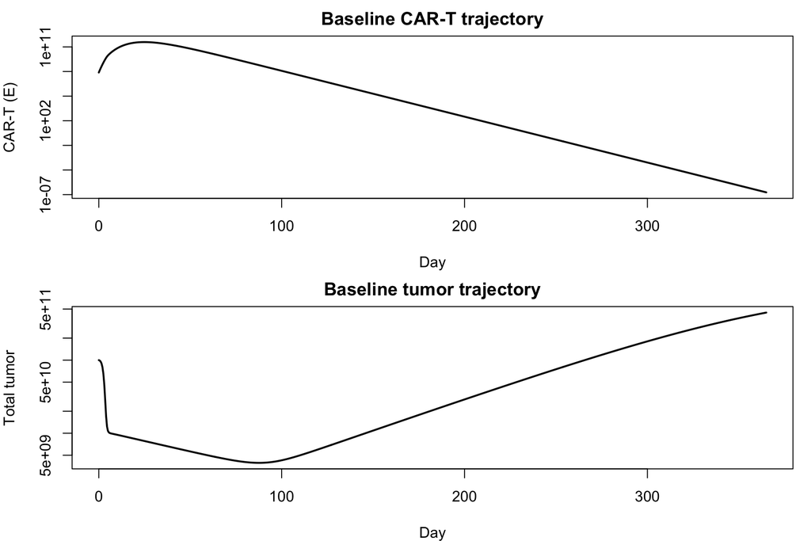

# 4 Summary metrics (log-transformed)

Eight scalar summaries corresponding to clinical observables. All log-transformed with floors so they behave well under any perturbation.

```
##       log_peak_E     log_t_peak_E     log_AUC_E_28     log_E_day180
##            11.59             1.40            12.71             3.62
##  log_tumor_day90 log_tumor_day365  log_sBCMA_AUC60  log_sBCMA_day30
##             9.60            11.65             1.54            -1.20
```

Every metric should be non-degenerate (not at floor). If any are, the baseline needs further adjustment before the sensitivity results carry meaning.

# 5 Local sensitivity analysis

## 5.1 Parameter selection

Same 16 parameters as v1: kinetic and pharmacological parameters, with antigen densities, `K_max`, and redundant shed rates excluded.

## 5.2 Log-log sensitivity coefficients

For each parameter, perturb by ±10% and compute

$$S_{ij} = \frac{\Delta \log_{10} M_j}{\Delta \log_{10} p_i}$$

This is the dimensionless log-log elasticity. Interpretation: `S = 1` means “a factor-of-2 change in parameter produces a factor-of-2 change in metric.” Values around 0 mean no effect; typical informative values are in the 0.1–5 range. Unlike the v1 linear-elasticity formula, this stays well-behaved even when metric values are tiny because the log transform absorbs the dynamic range.

```
##               log_peak_E log_t_peak_E log_AUC_E_28 log_E_day180 log_tumor_day90
## k_growth           10.84          0.5         9.96        12.45           -1.92
## k_decay_eff        -3.07         -0.5        -2.51       -22.78            1.36
## k_decay_mem        -0.03          0.0        -0.02        -0.21            0.01
## frac_mem            0.51          0.1         0.42         3.81           -0.23
## k_ld_recover       -7.19         -1.0        -5.82       -12.03            1.59
## Vmax_bival         -0.65          0.0        -0.65        -0.65            0.10
## EC50_bival          0.01          0.0         0.01         0.01            0.00
## n_bival            -0.02          0.0        -0.02        -0.02            0.00
## Vmax_mono           0.01          0.0         0.01         0.01           -3.03
## EC50_mono          -0.01          0.0        -0.01        -0.01            2.99
## n_mono             -0.02          0.0        -0.02        -0.02            5.63
## ET50                0.29          0.0         0.29         0.29            0.14
## k_prolif            0.01          0.0         0.01         0.01            1.98
## k_shed_high         0.02          0.0         0.02         0.02            0.00
## k_clear_sBCMA      -0.02          0.0        -0.02        -0.02            0.00
## Kd_sBCMA           -0.02          0.0        -0.02        -0.02            0.00
##               log_tumor_day365 log_sBCMA_AUC60 log_sBCMA_day30
## k_growth                 -2.10           -0.62           -0.15
## k_decay_eff               1.85            0.06            0.02
## k_decay_mem               0.02            0.00            0.00
## frac_mem                 -0.30           -0.01            0.00
## k_ld_recover              1.96            0.06            0.03
## Vmax_bival                0.11           -0.35            0.01
## EC50_bival                0.00            0.01            0.00
## n_bival                   0.00           -0.02            0.00
## Vmax_mono                -2.02           -0.09           -0.89
## EC50_mono                 2.03            0.08            0.88
## n_mono                    3.91            0.16            1.66
## ET50                      0.14            0.26            0.03
## k_prolif                  4.27            0.09            0.58
## k_shed_high               0.00            0.72            0.00
## k_clear_sBCMA             0.00           -1.00           -1.01
## Kd_sBCMA                  0.00           -0.02            0.00
```

## 5.3 Summary ranking

```
##      parameter total_abs max_abs n_significant
##       k_growth   38.5368 12.4496             8
##    k_decay_eff   32.1661 22.7829             6
##   k_ld_recover   29.6860 12.0307             6
##         n_mono   11.4139  5.6315             4
##       k_prolif    6.9677  4.2713             3
##      Vmax_mono    6.0495  3.0266             3
##      EC50_mono    6.0111  2.9897             3
##       frac_mem    5.3859  3.8061             6
##     Vmax_bival    2.5266  0.6530             5
##  k_clear_sBCMA    2.0670  1.0053             2
##           ET50    1.4349  0.2876             6
##    k_shed_high    0.7656  0.7151             1
##    k_decay_mem    0.2979  0.2144             1
##        n_bival    0.0821  0.0192             0
##       Kd_sBCMA    0.0789  0.0200             0
##     EC50_bival    0.0335  0.0124             0
```

## 5.4 Sensitivity heatmap

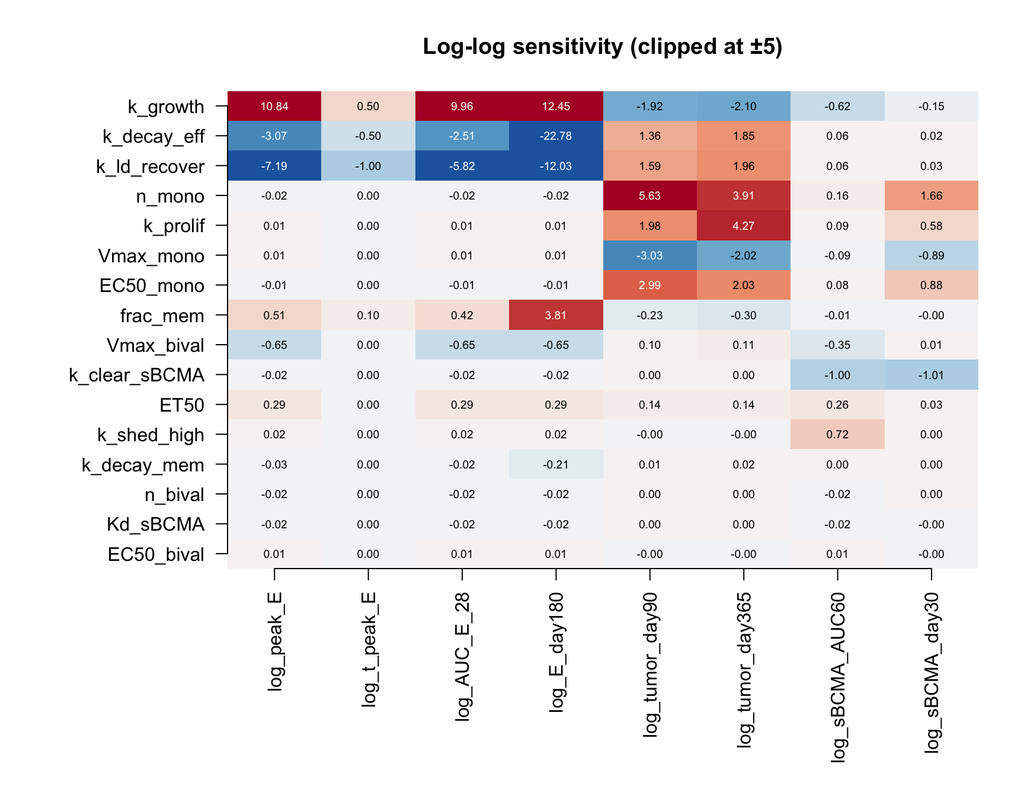

# 6 Time-resolved sensitivity for top drivers

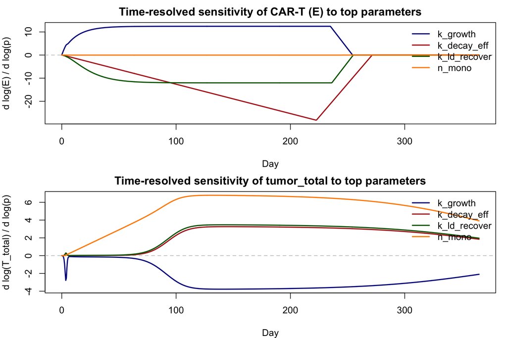

# 7 Practical identifiability

Two parameters are practically unidentifiable if their log-log sensitivity vectors are proportional. We compute the correlation between rows of the sensitivity matrix, restricted to parameters that actually have signal.

```
## Parameters with any signal (|S| > 0.01 somewhere): 16 of 16
```

```
## Excluded (no signal):
```

```
##               k_growth k_decay_eff k_decay_mem frac_mem k_ld_recover Vmax_bival
## k_growth          1.00       -0.72       -0.72     0.72        -0.97      -0.92
## k_decay_eff      -0.72        1.00        1.00    -1.00         0.87       0.61
## k_decay_mem      -0.72        1.00        1.00    -1.00         0.87       0.61
## frac_mem          0.72       -1.00       -1.00     1.00        -0.87      -0.61
## k_ld_recover     -0.97        0.87        0.87    -0.87         1.00       0.88
## Vmax_bival       -0.92        0.61        0.61    -0.61         0.88       1.00
## EC50_bival        0.47       -0.32       -0.32     0.32        -0.46      -0.76
## n_bival          -0.78        0.52        0.52    -0.51         0.75       0.96
## Vmax_mono         0.63       -0.41       -0.41     0.41        -0.63      -0.72
## EC50_mono        -0.63        0.41        0.41    -0.41         0.63       0.72
## n_mono           -0.63        0.41        0.41    -0.42         0.63       0.72
## ET50              0.70       -0.46       -0.47     0.46        -0.64      -0.85
## k_prolif         -0.56        0.37        0.37    -0.37         0.57       0.64
## k_shed_high      -0.24        0.14        0.14    -0.14         0.20      -0.13
## k_clear_sBCMA     0.37       -0.23       -0.23     0.24        -0.33      -0.14
## Kd_sBCMA         -0.74        0.49        0.50    -0.49         0.71       0.94
##               EC50_bival n_bival Vmax_mono EC50_mono n_mono  ET50 k_prolif
## k_growth            0.47   -0.78      0.63     -0.63  -0.63  0.70    -0.56
## k_decay_eff        -0.32    0.52     -0.41      0.41   0.41 -0.46     0.37
## k_decay_mem        -0.32    0.52     -0.41      0.41   0.41 -0.47     0.37
## frac_mem            0.32   -0.51      0.41     -0.41  -0.42  0.46    -0.37
## k_ld_recover       -0.46    0.75     -0.63      0.63   0.63 -0.64     0.57
## Vmax_bival         -0.76    0.96     -0.72      0.72   0.72 -0.85     0.64
## EC50_bival          1.00   -0.92      0.65     -0.65  -0.66  0.78    -0.58
## n_bival            -0.92    1.00     -0.74      0.74   0.74 -0.87     0.66
## Vmax_mono           0.65   -0.74      1.00     -1.00  -1.00  0.35    -0.79
## EC50_mono          -0.65    0.74     -1.00      1.00   1.00 -0.35     0.80
## n_mono             -0.66    0.74     -1.00      1.00   1.00 -0.35     0.81
## ET50                0.78   -0.87      0.35     -0.35  -0.35  1.00    -0.26
## k_prolif           -0.58    0.66     -0.79      0.80   0.81 -0.26     1.00
## k_shed_high         0.74   -0.41      0.25     -0.25  -0.25  0.31    -0.23
## k_clear_sBCMA      -0.33    0.06     -0.15      0.15   0.16  0.14     0.23
## Kd_sBCMA           -0.93    1.00     -0.71      0.71   0.71 -0.88     0.64
##               k_shed_high k_clear_sBCMA Kd_sBCMA
## k_growth            -0.24          0.37    -0.74
## k_decay_eff          0.14         -0.23     0.49
## k_decay_mem          0.14         -0.23     0.50
## frac_mem            -0.14          0.24    -0.49
## k_ld_recover         0.20         -0.33     0.71
## Vmax_bival          -0.13         -0.14     0.94
## EC50_bival           0.74         -0.33    -0.93
## n_bival             -0.41          0.06     1.00
## Vmax_mono            0.25         -0.15    -0.71
## EC50_mono           -0.25          0.15     0.71
## n_mono              -0.25          0.16     0.71
## ET50                 0.31          0.14    -0.88
## k_prolif            -0.23          0.23     0.64
## k_shed_high          1.00         -0.65    -0.46
## k_clear_sBCMA       -0.65          1.00     0.11
## Kd_sBCMA            -0.46          0.11     1.00
```

## 7.1 Flagging correlated pairs

```
##            p1           p2    cor              status
##   k_decay_eff     frac_mem -1.000      UNIDENTIFIABLE
##     Vmax_mono    EC50_mono -1.000      UNIDENTIFIABLE
##     EC50_mono       n_mono  1.000      UNIDENTIFIABLE
##   k_decay_eff  k_decay_mem  1.000      UNIDENTIFIABLE
##     Vmax_mono       n_mono -1.000      UNIDENTIFIABLE
##   k_decay_mem     frac_mem -1.000      UNIDENTIFIABLE
##       n_bival     Kd_sBCMA  0.997      UNIDENTIFIABLE
##      k_growth k_ld_recover -0.967      UNIDENTIFIABLE
##    Vmax_bival      n_bival  0.957      UNIDENTIFIABLE
##    Vmax_bival     Kd_sBCMA  0.941 strongly correlated
##    EC50_bival     Kd_sBCMA -0.934 strongly correlated
##      k_growth   Vmax_bival -0.923 strongly correlated
##    EC50_bival      n_bival -0.917 strongly correlated
##          ET50     Kd_sBCMA -0.883 strongly correlated
##  k_ld_recover   Vmax_bival  0.876 strongly correlated
##       n_bival         ET50 -0.874 strongly correlated
##   k_decay_mem k_ld_recover  0.867 strongly correlated
##   k_decay_eff k_ld_recover  0.867 strongly correlated
##      frac_mem k_ld_recover -0.866 strongly correlated
##    Vmax_bival         ET50 -0.852 strongly correlated
```

## 7.2 Correlation heatmap

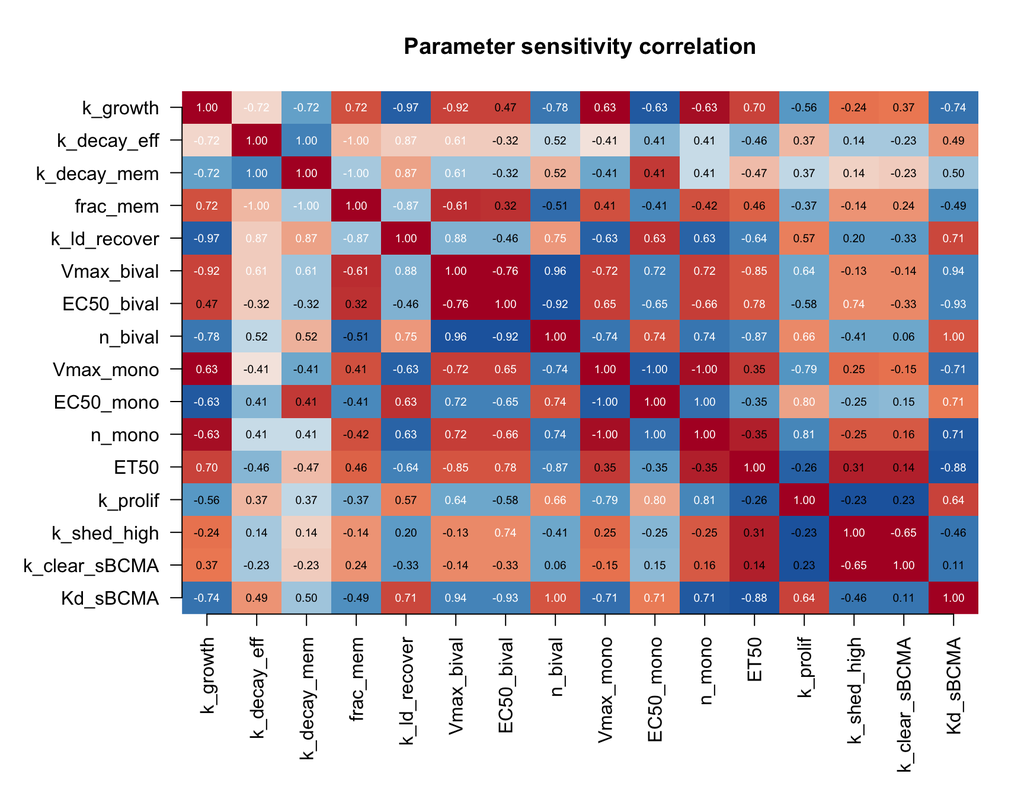

# 8 Recommendations for nlmixr2 fit

Apply these filters *after* reviewing the output above — they’re guidance, not a hard rule.

## 8.1 Fix to literature values

Parameters with `total_abs < 1` (essentially no signal across any observed metric at this baseline). Estimating these adds degrees of freedom without data to support them.

Parameters with `max_abs < 0.3` (no single metric moves much) are also fix candidates even if `total_abs` is moderate across many weak effects.

## 8.2 Estimate as typical value only (no BSV)

Moderate signal (`max_abs` between 0.3 and 1, `n_significant ≥ 2`) but strongly correlated (|cor| > 0.85) with another estimated parameter. Or: parameters where between-subject variability would be over-parameterization given typical sparse sampling.

## 8.3 Estimate with BSV (typical value + random effect)

Parameters meeting both:

- Strong signal: `max_abs > 1` in at least one metric
- Independent: |cor| < 0.85 with every other estimated parameter